# Time Series Models

Rob Leonard (robleonard@tamu.edu)

# Preliminary Setup

Download return data for Texas Instruments

```r
library("quantmod")
library("forecast")
library(rugarch)
library(patchwork)
source("ARMAroots_RFunctions.R")
options(scipen=999)

getSymbols("TXN", from = "2007-01-03", to = "2021-04-01")
```

[output not shown]

```
## [1] "TXN"
```

```r
sum(is.na(TXN))   # check for missing values
```

```
## [1] 0
```

```r
Yt = dailyReturn(Ad(TXN), type = "log")[-1]
head(Yt, 2)
```

```
##            daily.returns
## 2007-01-04    0.01873063
## 2007-01-05   -0.01175241
```

```r
tail(Yt, 2)
```

```
##            daily.returns
## 2021-03-30  -0.001289968
## 2021-03-31   0.016270147
```

```r
dim(Yt)
```

```
## [1] 3585    1
```

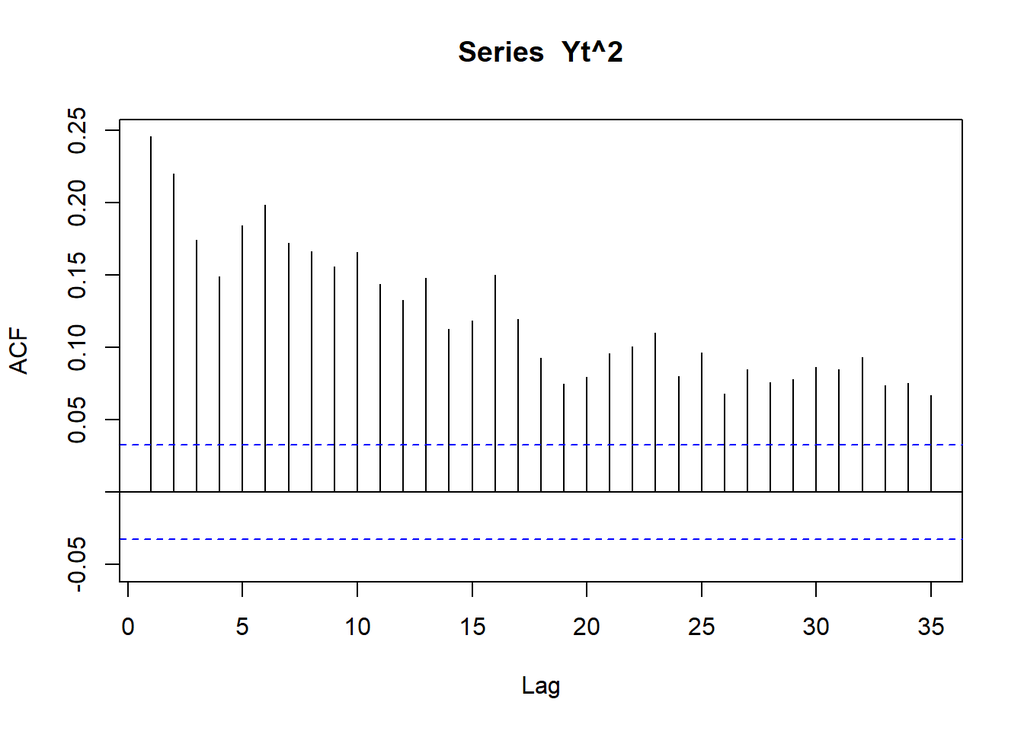

```r
Acf(Yt^2)         # chech for ARCH/GARCH
```

```r
ind = which(time(Yt) == "2016-12-30")
Yn = Yt[1:ind,]
dim(Yn)
```

```
## [1] 2517    1
```

```r
save.image("garch.RData")
```

# Questions 1

**1a) Find a distribution that is the best fit.**

```r
dists = c("std", "sstd", "ged", "sged")
fits = vector("list", 4)
for(i in 1:4) fits[[i]] = fitdist(dists[i], Yn)
```

Plot densities.

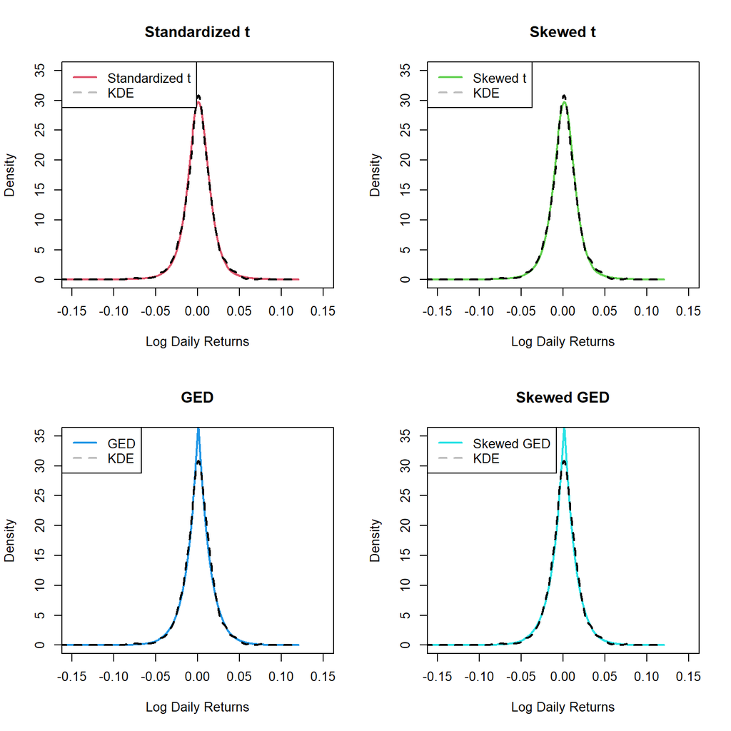

```r
par(mfrow = c(2, 2))
den = density(Yn)  # store kernel density estimates
labels = c("Standardized t", "Skewed t", "GED", "Skewed GED")
for (i in 1:4) {
  est = fits[[i]]$pars
  yvals = ddist(dists[i], den$x, mu = est["mu"], sigma = est["sigma"], skew = est["skew"], shape = est["shape"])
  plot(den$x, yvals, type="l", lwd=2, col=i+1, xlab="Log Daily Returns", ylab="Density", main=labels[i], xlim = c(-.15,.15), ylim = c(0,35))
  lines(den$x, den$y, lwd=2, lty=2, col="black") # Kernel Density
  legend("topleft", c(labels[i],"KDE"),  lwd=c(2,2), lty=c(1,2), col = c(i+1, "gray"))
}
```

Either the stardized or skewed t fit the best based on these plots. The GED and skewed GED are too peaked. Zoom in on the first 2 plots:

[figure not shown]

```r
# zoom in on standardized and skew t peaks
par(mfrow = c(1,2))
for (i in 1:2) {
  est = fits[[i]]$pars
  yvals = ddist(dists[i], den$x, mu = est["mu"], sigma = est["sigma"], skew = est["skew"], shape = est["shape"])
  plot(den$x, yvals, type="l", lwd=2, col=i+1, xlab="Log Weekly Returns", ylab="Density", main=labels[i], xlim = c(-.05,.05), ylim = c(0,30))
  lines(den$x, den$y, lwd=2, lty=2, col="black") # Kernel Density
  legend("topleft", c(labels[i],"KDE"),  lwd=c(2,2), lty=c(1,2), col = c(i+1, "gray"), cex=.7)
}
```

Compute AIC and BIC:

```r
AIC_dist  = BIC_dist = rep(0,2)  # set up results vectors
BIC_dist  = rep(0,2)
for (i in 1:2) {
  logLike      = min(fits[[i]]$values)
  numbParam    = length(fits[[i]]$pars) # count # parameters used for each
  AIC_dist[i]  = 2*logLike + 2*numbParam  # from p. 54 HO 3 fitdist() gives -loglikelihood,  use last value
  BIC_dist[i]  = 2*logLike + numbParam*log(length(Yn))  # formulas on p. 55, fix this not length(rt)
}
aicStt = round(AIC_dist[1],0)
bicStt = round(BIC_dist[1],0)
aicSkt = round(AIC_dist[2],0)
bicSkt = round(BIC_dist[2],0)
```

|  | Standardized t | Skewed t |
| --- | --- | --- |
| **AIC** | -13422 | -13422 |
| **BIC** | -13405 | -13398 |

```r
sigmaDistb = sqrt(diag(solve(fits[[2]]$hessian)))  # skew is parameter 3 for both distributions
lowerDistb = fits[[2]]$pars[3] - 1.96*sigmaDistb[3]
upperDistb = fits[[2]]$pars[3] + 1.96*sigmaDistb[3]
```

The 95% CI for skewness for the Skewed t distribution is (0.92,1.019).  
Since the CI contains 1, we don’t have evidence to reject the null hypothesis that the distribution is symmetric. Thus, the **standardized t distribution** will be used. The paramters are as follows:

```r
cat("The estimated standarized t distribution parameters are: \n", "mu \t", "sigma \t", "shape \n", round(fits[[1]]$pars,5))
```

```
## The estimated standarized t distribution parameters are:
##  mu   sigma   shape
##  0.00075 0.01879 3.60028
```

**1b) Plot qq plot.**

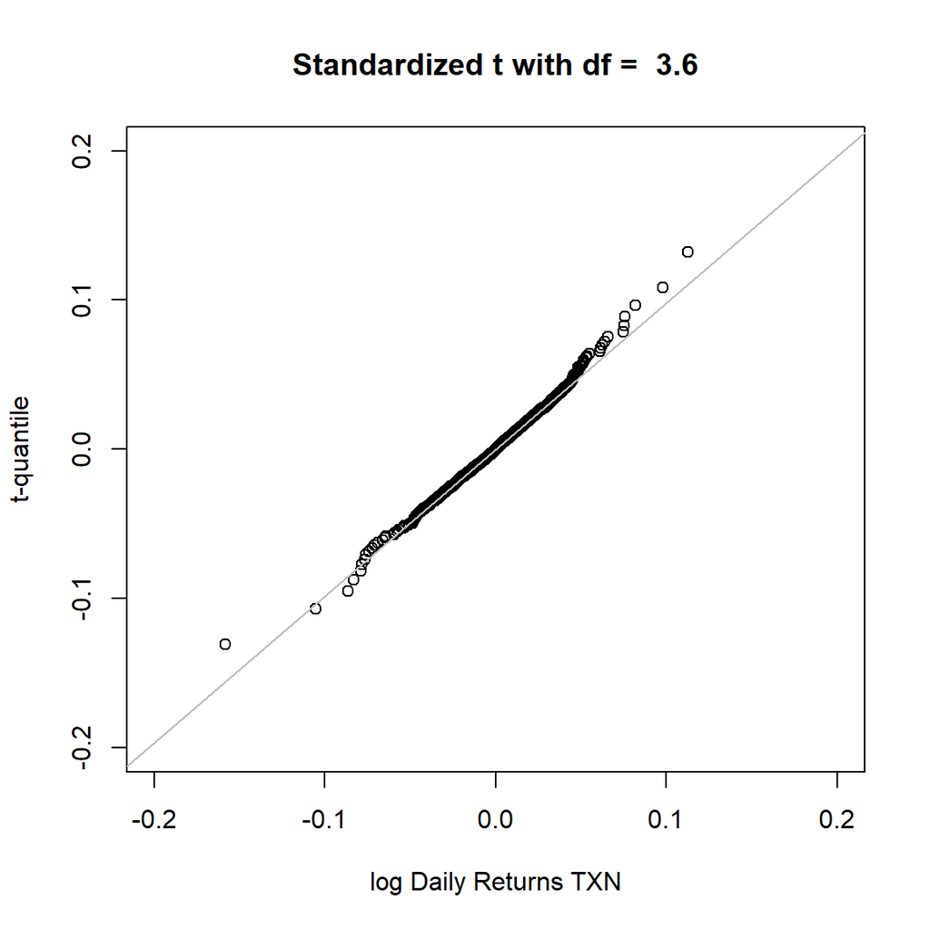

```r
par(mfrow = c(1, 1))
n         = length(Yn)
q_grid    = (1:n) / (n + 1)
df = fits[[1]]$pars[3]
returns = as.vector(Yn)

# calc abline for quantile
temp1 = quantile(qdist(distribution = "std", p=q_grid, mu=fits[[1]]$pars[1], sigma = fits[[1]]$pars[2], shape = fits[[1]]$pars[3]), c(0.25,0.75))
temp2 = quantile(Yn, c(0.25, 0.75))
temp3 = lsfit(temp1,temp2)

#qq plot
qqplot(returns, qdist(distribution = "std", p=q_grid, mu=fits[[1]]$pars[1], sigma = fits[[1]]$pars[2], shape = fits[[1]]$pars[3]), main = paste("Standardized t with df = ", round(df,2)), ylab="t-quantile", xlab="log Daily Returns TXN", xlim = c(-.2,.2), ylim = c(-.2,.2) )
abline(temp3$coef, col = "gray")
```

The QQ plot shows that the standardized t-distribution with 3.6 degrees of freedom fits fairly well to the daily log return data for Texas Instruments, with only very slight deviation in the tails.

# Question 2: Fit an ARMA Model

**Data Descritption**

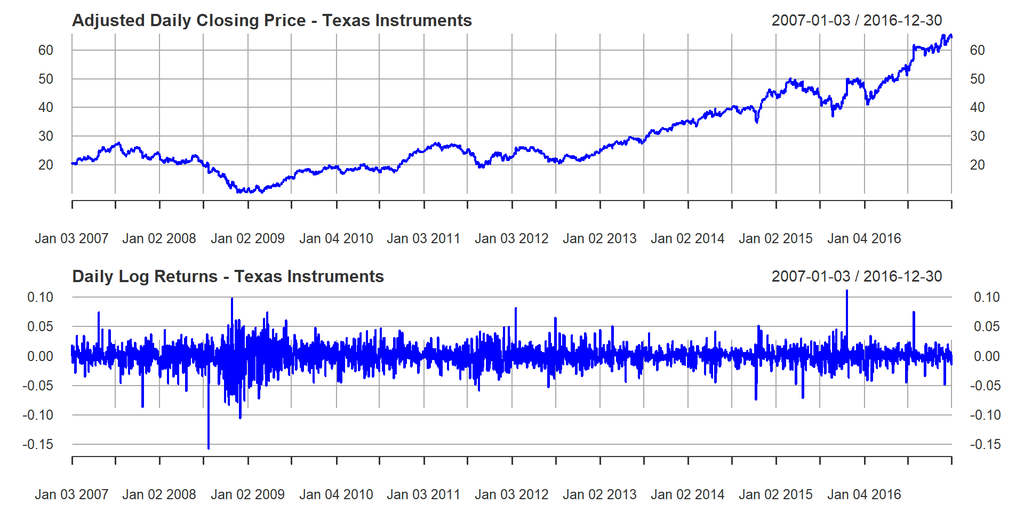

```r
par(mfrow   = c(2, 1))
plot(Ad(TXN["2007-01-03::2016-12-30"]), main="Adjusted Daily Closing Price - Texas Instruments", col="blue")
plot(dailyReturn(Ad(TXN["2007-01-03::2016-12-30"]), type="log"), main="Daily Log Returns - Texas Instruments", col="blue")
```

**Data Exploration**

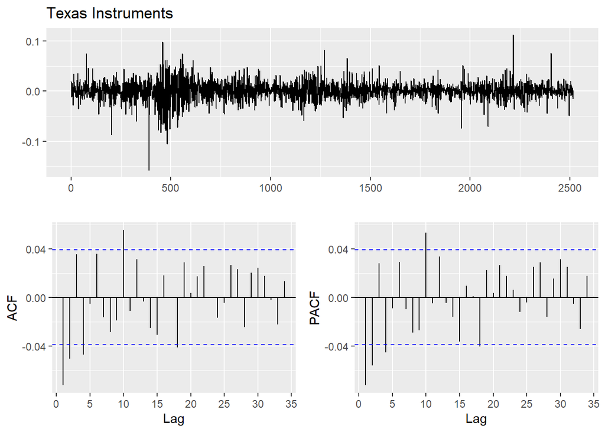

```r
ggtsdisplay(Yn, points = F, main = "Texas Instruments")
```

Lags in periods 1 and 2 are generally the strongest. AR and MA models with a maximum of 2 would likely work best. For the autosearch, 4 will be used for conservatism, but models with 3 or 4 are unlikely.

**Find Candidate Models**

```r
auto.arima(Yn, max.p = 4, max.q = 4, seasonal = F, ic ="bic" )
```

```
## Series: Yn
## ARIMA(0,0,1) with zero mean
##
## Coefficients:
##           ma1
##       -0.0794
## s.e.   0.0208
##
## sigma^2 estimated as 0.0003275:  log likelihood=6527.41
## AIC=-13050.81   AICc=-13050.81   BIC=-13039.15
```

```r
auto.arima(Yn, max.p = 4, max.q = 4, seasonal = F, ic ="aic" )
```

```
## Series: Yn
## ARIMA(1,0,2) with zero mean
##
## Coefficients:
##           ar1     ma1      ma2
##       -0.4850  0.4125  -0.0898
## s.e.   0.1623  0.1620   0.0202
##
## sigma^2 estimated as 0.0003265:  log likelihood=6532.04
## AIC=-13056.07   AICc=-13056.06   BIC=-13032.75
```

The AIC chosen model isn’t reasonable. The coefficients are simply way too high for the low amount of correlation exhibited in the prior plots. The BIC model looks more appealing and likely. The ma2 coefficient from the AIC chosen model also matches up well with the BIC chosen model and is much more reasonable. Multiple models will be tested further with a maximum of 2 for either/both p and q.

**Model Selection**  
Explore 8 different model fits, although some are already fairly unlikely to work.  
AR models with p = 1,2. MA models with q = 1,2. ARMA models with all 4 combinations of p,q.

```r
# MA(1)
fit.MA1     = Arima(Yn, order = c(0,0,1), seasonal = FALSE, include.mean = FALSE)
plot.MA1    = autoplot_roots(fit.MA1)
MA1c1       = as.numeric(round(fit.MA1$coef[1],3))
MA1AIC      = round(fit.MA1$aicc,0)
MA1BIC      = round(fit.MA1$bic,0)

# MA(2)
fit.MA2     = Arima(Yn, order = c(0,0,2), seasonal = FALSE, include.mean = FALSE)
plot.MA2    = autoplot_roots(fit.MA2)
MA2c1       = as.numeric(round(fit.MA2$coef[1],3))
MA2c2       = as.numeric(round(fit.MA2$coef[2],3))
MA2AIC      = round(fit.MA2$aicc,0)
MA2BIC      = round(fit.MA2$bic,0)

# AR(1)
fit.AR1     = Arima(Yn, order = c(1,0,0), seasonal = FALSE, include.mean = FALSE)
plot.AR1    = autoplot_roots(fit.AR1)
AR1c1       = as.numeric(round(fit.AR1$coef[1],3))
AR1AIC      = round(fit.AR1$aicc,0)
AR1BIC      = round(fit.AR1$bic,0)

# AR(2)
fit.AR2     = Arima(Yn, order = c(2,0,0), seasonal = FALSE, include.mean = FALSE)
plot.AR2    = autoplot_roots(fit.AR2)
AR2c1       = as.numeric(round(fit.AR2$coef[1],3))
AR2c2       = as.numeric(round(fit.AR2$coef[2],3))
AR2AIC      = round(fit.AR2$aicc,0)
AR2BIC      = round(fit.AR2$bic,0)

# ARMA(1,1)
fit.ARMA11  = Arima(Yn, order = c(1,0,1), seasonal = FALSE, include.mean = FALSE)
plot.ARMA11 = autoplot_roots(fit.ARMA11)
ARMA11c1       = as.numeric(round(fit.ARMA11$coef[1],3))
ARMA11c2       = as.numeric(round(fit.ARMA11$coef[2],3))
ARMA11AIC      = round(fit.ARMA11$aicc,0)
ARMA11BIC      = round(fit.ARMA11$bic,0)

# ARMA(2,2)
fit.ARMA22  = Arima(Yn, order = c(2,0,2), seasonal = FALSE, include.mean = FALSE)
plot.ARMA22 = autoplot_roots(fit.ARMA22)
ARMA22c1       = as.numeric(round(fit.ARMA22$coef[1],3))
ARMA22c2       = as.numeric(round(fit.ARMA22$coef[2],3))
ARMA22c3       = as.numeric(round(fit.ARMA22$coef[3],3))
ARMA22c4       = as.numeric(round(fit.ARMA22$coef[4],3))
ARMA22AIC      = round(fit.ARMA22$aicc,0)
ARMA22BIC      = round(fit.ARMA22$bic,0)

# ARMA(1,2)
fit.ARMA12  = Arima(Yn, order = c(1,0,2), seasonal = FALSE, include.mean = FALSE)
plot.ARMA12 = autoplot_roots(fit.ARMA12)
ARMA12c1       = as.numeric(round(fit.ARMA12$coef[1],3))
ARMA12c2       = as.numeric(round(fit.ARMA12$coef[2],3))
ARMA12c3       = as.numeric(round(fit.ARMA12$coef[3],3))
ARMA12AIC      = round(fit.ARMA12$aicc,0)
ARMA12BIC      = round(fit.ARMA12$bic,0)

# ARMA(2,1)
fit.ARMA21  = Arima(Yn, order = c(2,0,1), seasonal = FALSE, include.mean = FALSE)
plot.ARMA21 = autoplot_roots(fit.ARMA21)
ARMA21c1       = as.numeric(round(fit.ARMA21$coef[1],3))
ARMA21c2       = as.numeric(round(fit.ARMA21$coef[2],3))
ARMA21c3       = as.numeric(round(fit.ARMA21$coef[3],3))
ARMA21AIC      = round(fit.ARMA21$aicc,0)
ARMA21BIC      = round(fit.ARMA21$bic,0)
```

Plots of the polynomial roots for each model are shown below and are labeled as figures A through H. Also shown below is a table of the relevant model coefficients and associated corrected AIC and BIC values for model comparison.

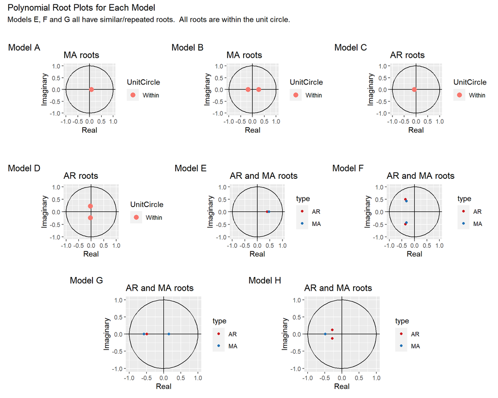

```r
(plot.MA1|plot.MA2|plot.AR1) / (plot.AR2|plot.ARMA11|plot.ARMA22) /(plot.ARMA12|plot.ARMA21)  + plot_annotation(
  title = 'Polynomial Root Plots for Each Model',
  subtitle = 'Models E, F and G all have similar/repeated roots.  All roots are within the unit circle.',
  tag_levels = "A", tag_prefix = 'Model ')
```

*Table 1: Model coefficients, corrected AIC & BIC scores*

[output not shown]

Models E through H are simply not feasible. Most of these have duplicate/similar roots so information is being repeated. Models A through D all have very similar AIC and BIC scores and each has unique roots within the unit circle. These 4 models will be explored further by examining residuals.

**Check Model Residuals**

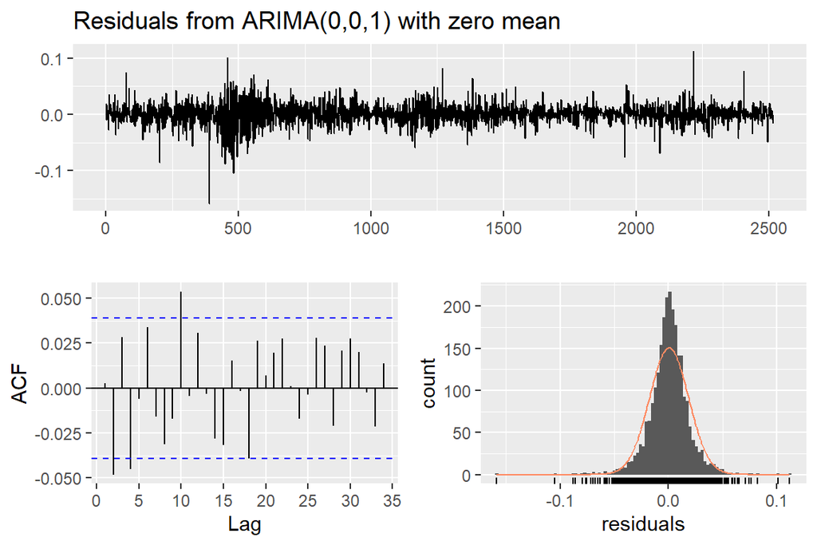

```
##
##  Ljung-Box test
##
## data:  Residuals from ARIMA(0,0,1) with zero mean
## Q* = 27.096, df = 9, p-value = 0.001349
##
## Model df: 1.   Total lags used: 10
```

```r
plot.resA = checkresiduals(fit.MA1, points = FALSE)
```

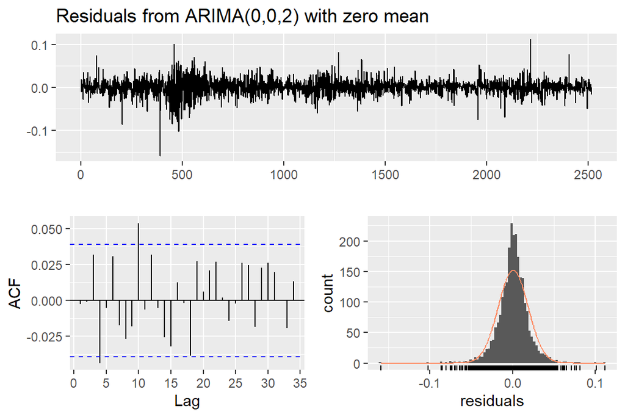

```
##
##  Ljung-Box test
##
## data:  Residuals from ARIMA(0,0,2) with zero mean
## Q* = 20.606, df = 8, p-value = 0.00827
##
## Model df: 2.   Total lags used: 10
```

```r
plot.resB = checkresiduals(fit.MA2, points = FALSE)
```

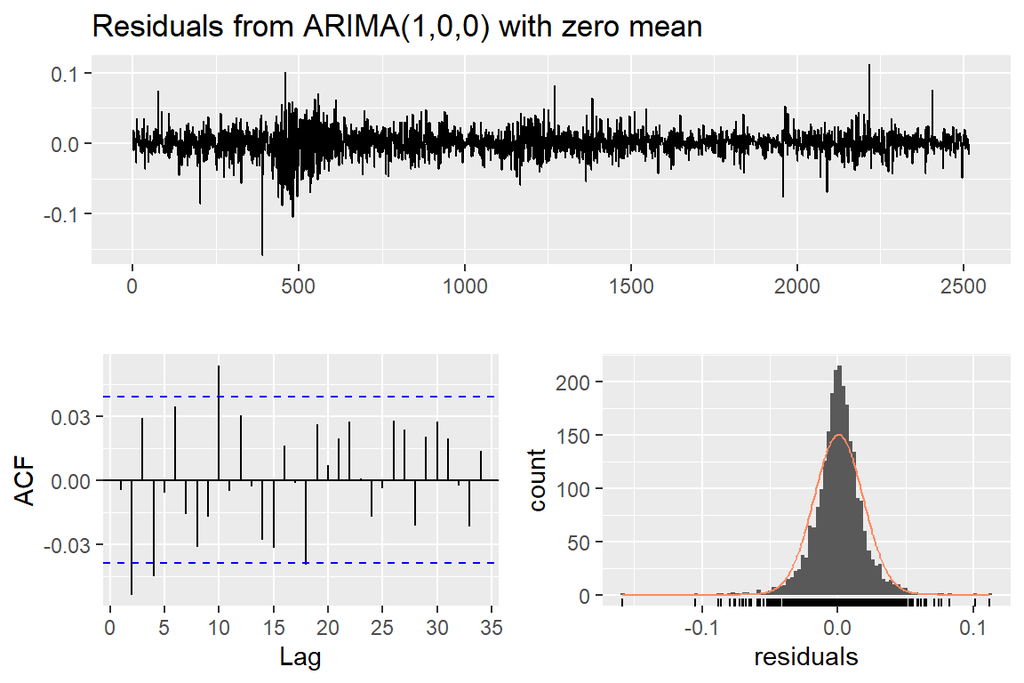

```
##
##  Ljung-Box test
##
## data:  Residuals from ARIMA(1,0,0) with zero mean
## Q* = 28.871, df = 9, p-value = 0.0006813
##
## Model df: 1.   Total lags used: 10
```

```r
plot.resC = checkresiduals(fit.AR1, points = FALSE)
```

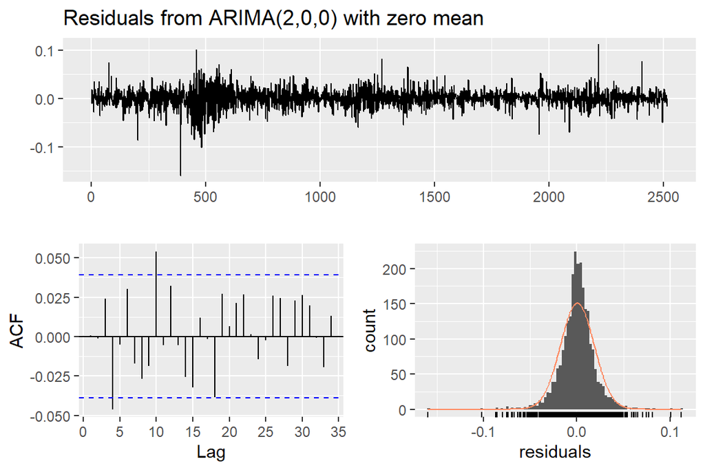

```
##
##  Ljung-Box test
##
## data:  Residuals from ARIMA(2,0,0) with zero mean
## Q* = 20.036, df = 8, p-value = 0.0102
##
## Model df: 2.   Total lags used: 10
```

```r
plot.resD = checkresiduals(fit.AR2, points = FALSE)
```

# Question 3: Forecasting

**3) Give the 1-, 2- and 3-step-ahead point forecasts and the corresponding 95% prediction intervals.**

```r
fore3.out = predict(fit.MA2, n.ahead=3)
PIlow = PIhi = rep(0,3)
q3 = quantile(qdist(distribution = "std", p=q_grid, mu=fits[[1]]$pars[1], sigma = fits[[1]]$pars[2], shape = fits[[1]]$pars[3]),.975)
for (i in 1:3){
  PIlow[i] = fore3.out$pred[i] - q3 * fore3.out$se[i]
  PIhi[i] = fore3.out$pred[i] + q3 * fore3.out$se[i]
}
```

[output not shown]

**3b) Use Calculate the k-step-ahead point forecasts and the corresponding 90% and 95% prediction intervals for k = 1, 2, . . . , 100 with forecast(). Assign an object for the return value, please do not display them. Please plot the forecast.**

```
## geom_path: Each group consists of only one observation. Do you need to adjust
## the group aesthetic?
```

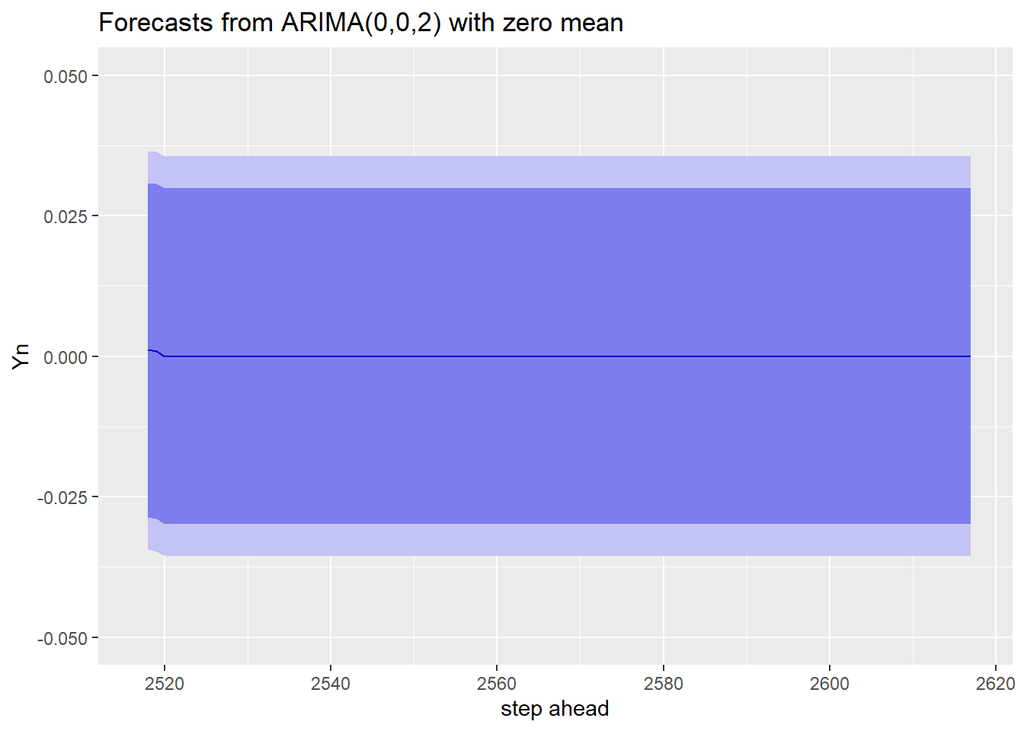

```r
pred3b = forecast(fit.MA2, h=100, level = c(90,95))
autoplot(pred3b, xlim=c(2517,2617), ylim = c(-.05,.05), xlab = "step ahead")
```